# Credit Card Fraud Detection

## Business Problem

Financial institutions need to identify potentially fraudulent transactions while minimizing the number of legitimate transactions incorrectly flagged for investigation.

This project analyzes credit card transactions to:

1. Understand the characteristics of fraudulent transactions.
2. Identify transaction-level patterns associated with fraud.
3. Investigate whether transaction timing and transaction value are associated with higher fraud risk.
4. Use SQL to answer targeted business questions.
5. Apply Isolation Forest to identify anomalous transactions.
6. Evaluate how well detected anomalies align with known fraudulent transactions.
7. Translate analytical findings into practical fraud-monitoring recommendations.

## Analytical Approach

The analysis combines:

- **Python** for data preparation, exploratory analysis and anomaly detection.
- **SQL / SQLite** for targeted transaction analysis.
- **Statistical analysis** to compare fraudulent and legitimate transactions.
- **Isolation Forest** for unsupervised anomaly detection.

This project analyzes the [Kaggle Credit Card Fraud Detection dataset](https://www.kaggle.com/datasets/mlg-ulb/creditcardfraud) to identify fraudulent transactions using SQLite, pandas and machine learning in Python.

```python
import pandas as pd
import numpy as np
import sqlite3

import matplotlib.pyplot as plt
import seaborn as sns

from sklearn.model_selection import train_test_split
from sklearn.ensemble import IsolationForest
from sklearn.metrics import (
    classification_report,
    confusion_matrix,
    precision_score,
    recall_score,
    f1_score
)

pd.set_option("display.max_columns", None)

sns.set_theme(style="whitegrid")
```

### Library Imports

- `sqlite3`: For creating and querying a SQLite database.
- `pandas`: For data manipulation and analysis.
- `numpy`: For numerical operations.
- `sklearn.ensemble.IsolationForest`: For anomaly detection.
- `sklearn.metrics`: For model evaluation (confusion matrix and classification report).
- `matplotlib` and `seaborn`: For data visualization.

## 1. Data Loading

The dataset contains 284,807 credit card transactions made over approximately two days.

The available variables include:

- `Time`: seconds elapsed since the first transaction.
- `V1`–`V28`: anonymized transaction features.
- `Amount`: transaction amount.
- `Class`: target variable where 0 represents legitimate transactions and 1 represents fraud.

```python
df = pd.read_csv("creditcard.csv")

df.head(20)
```

|  | Time | V1 | V2 | V3 | V4 | V5 | V6 | V7 | V8 | V9 | V10 | V11 | V12 | V13 | V14 | V15 | V16 | V17 | V18 | V19 | V20 | V21 | V22 | V23 | V24 | V25 | V26 | V27 | V28 | … |
| --- | --- | --- | --- | --- | --- | --- | --- | --- | --- | --- | --- | --- | --- | --- | --- | --- | --- | --- | --- | --- | --- | --- | --- | --- | --- | --- | --- | --- | --- | --- |
| 0 | 0.0 | -1.359807 | -0.072781 | 2.536347 | 1.378155 | -0.338321 | 0.462388 | 0.239599 | 0.098698 | 0.363787 | 0.090794 | -0.551600 | -0.617801 | -0.991390 | -0.311169 | 1.468177 | -0.470401 | 0.207971 | 0.025791 | 0.403993 | 0.251412 | -0.018307 | 0.277838 | -0.110474 | 0.066928 | 0.128539 | -0.189115 | 0.133558 | -0.021053 | … |
| 1 | 0.0 | 1.191857 | 0.266151 | 0.166480 | 0.448154 | 0.060018 | -0.082361 | -0.078803 | 0.085102 | -0.255425 | -0.166974 | 1.612727 | 1.065235 | 0.489095 | -0.143772 | 0.635558 | 0.463917 | -0.114805 | -0.183361 | -0.145783 | -0.069083 | -0.225775 | -0.638672 | 0.101288 | -0.339846 | 0.167170 | 0.125895 | -0.008983 | 0.014724 | … |
| 2 | 1.0 | -1.358354 | -1.340163 | 1.773209 | 0.379780 | -0.503198 | 1.800499 | 0.791461 | 0.247676 | -1.514654 | 0.207643 | 0.624501 | 0.066084 | 0.717293 | -0.165946 | 2.345865 | -2.890083 | 1.109969 | -0.121359 | -2.261857 | 0.524980 | 0.247998 | 0.771679 | 0.909412 | -0.689281 | -0.327642 | -0.139097 | -0.055353 | -0.059752 | … |
| 3 | 1.0 | -0.966272 | -0.185226 | 1.792993 | -0.863291 | -0.010309 | 1.247203 | 0.237609 | 0.377436 | -1.387024 | -0.054952 | -0.226487 | 0.178228 | 0.507757 | -0.287924 | -0.631418 | -1.059647 | -0.684093 | 1.965775 | -1.232622 | -0.208038 | -0.108300 | 0.005274 | -0.190321 | -1.175575 | 0.647376 | -0.221929 | 0.062723 | 0.061458 | … |
| 4 | 2.0 | -1.158233 | 0.877737 | 1.548718 | 0.403034 | -0.407193 | 0.095921 | 0.592941 | -0.270533 | 0.817739 | 0.753074 | -0.822843 | 0.538196 | 1.345852 | -1.119670 | 0.175121 | -0.451449 | -0.237033 | -0.038195 | 0.803487 | 0.408542 | -0.009431 | 0.798278 | -0.137458 | 0.141267 | -0.206010 | 0.502292 | 0.219422 | 0.215153 | … |
| 5 | 2.0 | -0.425966 | 0.960523 | 1.141109 | -0.168252 | 0.420987 | -0.029728 | 0.476201 | 0.260314 | -0.568671 | -0.371407 | 1.341262 | 0.359894 | -0.358091 | -0.137134 | 0.517617 | 0.401726 | -0.058133 | 0.068653 | -0.033194 | 0.084968 | -0.208254 | -0.559825 | -0.026398 | -0.371427 | -0.232794 | 0.105915 | 0.253844 | 0.081080 | … |
| 6 | 4.0 | 1.229658 | 0.141004 | 0.045371 | 1.202613 | 0.191881 | 0.272708 | -0.005159 | 0.081213 | 0.464960 | -0.099254 | -1.416907 | -0.153826 | -0.751063 | 0.167372 | 0.050144 | -0.443587 | 0.002821 | -0.611987 | -0.045575 | -0.219633 | -0.167716 | -0.270710 | -0.154104 | -0.780055 | 0.750137 | -0.257237 | 0.034507 | 0.005168 | … |
| 7 | 7.0 | -0.644269 | 1.417964 | 1.074380 | -0.492199 | 0.948934 | 0.428118 | 1.120631 | -3.807864 | 0.615375 | 1.249376 | -0.619468 | 0.291474 | 1.757964 | -1.323865 | 0.686133 | -0.076127 | -1.222127 | -0.358222 | 0.324505 | -0.156742 | 1.943465 | -1.015455 | 0.057504 | -0.649709 | -0.415267 | -0.051634 | -1.206921 | -1.085339 | … |
| 8 | 7.0 | -0.894286 | 0.286157 | -0.113192 | -0.271526 | 2.669599 | 3.721818 | 0.370145 | 0.851084 | -0.392048 | -0.410430 | -0.705117 | -0.110452 | -0.286254 | 0.074355 | -0.328783 | -0.210077 | -0.499768 | 0.118765 | 0.570328 | 0.052736 | -0.073425 | -0.268092 | -0.204233 | 1.011592 | 0.373205 | -0.384157 | 0.011747 | 0.142404 | … |
| 9 | 9.0 | -0.338262 | 1.119593 | 1.044367 | -0.222187 | 0.499361 | -0.246761 | 0.651583 | 0.069539 | -0.736727 | -0.366846 | 1.017614 | 0.836390 | 1.006844 | -0.443523 | 0.150219 | 0.739453 | -0.540980 | 0.476677 | 0.451773 | 0.203711 | -0.246914 | -0.633753 | -0.120794 | -0.385050 | -0.069733 | 0.094199 | 0.246219 | 0.083076 | … |
| 10 | 10.0 | 1.449044 | -1.176339 | 0.913860 | -1.375667 | -1.971383 | -0.629152 | -1.423236 | 0.048456 | -1.720408 | 1.626659 | 1.199644 | -0.671440 | -0.513947 | -0.095045 | 0.230930 | 0.031967 | 0.253415 | 0.854344 | -0.221365 | -0.387226 | -0.009302 | 0.313894 | 0.027740 | 0.500512 | 0.251367 | -0.129478 | 0.042850 | 0.016253 | … |
| 11 | 10.0 | 0.384978 | 0.616109 | -0.874300 | -0.094019 | 2.924584 | 3.317027 | 0.470455 | 0.538247 | -0.558895 | 0.309755 | -0.259116 | -0.326143 | -0.090047 | 0.362832 | 0.928904 | -0.129487 | -0.809979 | 0.359985 | 0.707664 | 0.125992 | 0.049924 | 0.238422 | 0.009130 | 0.996710 | -0.767315 | -0.492208 | 0.042472 | -0.054337 | … |
| 12 | 10.0 | 1.249999 | -1.221637 | 0.383930 | -1.234899 | -1.485419 | -0.753230 | -0.689405 | -0.227487 | -2.094011 | 1.323729 | 0.227666 | -0.242682 | 1.205417 | -0.317631 | 0.725675 | -0.815612 | 0.873936 | -0.847789 | -0.683193 | -0.102756 | -0.231809 | -0.483285 | 0.084668 | 0.392831 | 0.161135 | -0.354990 | 0.026416 | 0.042422 | … |
| 13 | 11.0 | 1.069374 | 0.287722 | 0.828613 | 2.712520 | -0.178398 | 0.337544 | -0.096717 | 0.115982 | -0.221083 | 0.460230 | -0.773657 | 0.323387 | -0.011076 | -0.178485 | -0.655564 | -0.199925 | 0.124005 | -0.980496 | -0.982916 | -0.153197 | -0.036876 | 0.074412 | -0.071407 | 0.104744 | 0.548265 | 0.104094 | 0.021491 | 0.021293 | … |
| 14 | 12.0 | -2.791855 | -0.327771 | 1.641750 | 1.767473 | -0.136588 | 0.807596 | -0.422911 | -1.907107 | 0.755713 | 1.151087 | 0.844555 | 0.792944 | 0.370448 | -0.734975 | 0.406796 | -0.303058 | -0.155869 | 0.778265 | 2.221868 | -1.582122 | 1.151663 | 0.222182 | 1.020586 | 0.028317 | -0.232746 | -0.235557 | -0.164778 | -0.030154 | … |
| 15 | 12.0 | -0.752417 | 0.345485 | 2.057323 | -1.468643 | -1.158394 | -0.077850 | -0.608581 | 0.003603 | -0.436167 | 0.747731 | -0.793981 | -0.770407 | 1.047627 | -1.066604 | 1.106953 | 1.660114 | -0.279265 | -0.419994 | 0.432535 | 0.263451 | 0.499625 | 1.353650 | -0.256573 | -0.065084 | -0.039124 | -0.087086 | -0.180998 | 0.129394 | … |
| 16 | 12.0 | 1.103215 | -0.040296 | 1.267332 | 1.289091 | -0.735997 | 0.288069 | -0.586057 | 0.189380 | 0.782333 | -0.267975 | -0.450311 | 0.936708 | 0.708380 | -0.468647 | 0.354574 | -0.246635 | -0.009212 | -0.595912 | -0.575682 | -0.113910 | -0.024612 | 0.196002 | 0.013802 | 0.103758 | 0.364298 | -0.382261 | 0.092809 | 0.037051 | … |
| 17 | 13.0 | -0.436905 | 0.918966 | 0.924591 | -0.727219 | 0.915679 | -0.127867 | 0.707642 | 0.087962 | -0.665271 | -0.737980 | 0.324098 | 0.277192 | 0.252624 | -0.291896 | -0.184520 | 1.143174 | -0.928709 | 0.680470 | 0.025436 | -0.047021 | -0.194796 | -0.672638 | -0.156858 | -0.888386 | -0.342413 | -0.049027 | 0.079692 | 0.131024 | … |
| 18 | 14.0 | -5.401258 | -5.450148 | 1.186305 | 1.736239 | 3.049106 | -1.763406 | -1.559738 | 0.160842 | 1.233090 | 0.345173 | 0.917230 | 0.970117 | -0.266568 | -0.479130 | -0.526609 | 0.472004 | -0.725481 | 0.075081 | -0.406867 | -2.196848 | -0.503600 | 0.984460 | 2.458589 | 0.042119 | -0.481631 | -0.621272 | 0.392053 | 0.949594 | … |
| 19 | 15.0 | 1.492936 | -1.029346 | 0.454795 | -1.438026 | -1.555434 | -0.720961 | -1.080664 | -0.053127 | -1.978682 | 1.638076 | 1.077542 | -0.632047 | -0.416957 | 0.052011 | -0.042979 | -0.166432 | 0.304241 | 0.554432 | 0.054230 | -0.387910 | -0.177650 | -0.175074 | 0.040002 | 0.295814 | 0.332931 | -0.220385 | 0.022298 | 0.007602 | … |

```python
print(f"Dataset shape: {df.shape}")
```

```
Dataset shape: (284807, 31)
```

```python
df.info()
```

```
<class 'pandas.core.frame.DataFrame'>
RangeIndex: 284807 entries, 0 to 284806
Data columns (total 31 columns):
 #   Column  Non-Null Count   Dtype
---  ------  --------------   -----
 0   Time    284807 non-null  float64
 1   V1      284807 non-null  float64
 2   V2      284807 non-null  float64
 3   V3      284807 non-null  float64
 4   V4      284807 non-null  float64
 5   V5      284807 non-null  float64
 6   V6      284807 non-null  float64
 7   V7      284807 non-null  float64
 8   V8      284807 non-null  float64
 9   V9      284807 non-null  float64
```

[output cut: 23 more lines]

```python
df.describe()
```

|  | Time | V1 | V2 | V3 | V4 | V5 | V6 | V7 | V8 | V9 | V10 | V11 | V12 | V13 | V14 | V15 | V16 | V17 | V18 | V19 | V20 | V21 | V22 | V23 | V24 | V25 | V26 | V27 | V28 | … |
| --- | --- | --- | --- | --- | --- | --- | --- | --- | --- | --- | --- | --- | --- | --- | --- | --- | --- | --- | --- | --- | --- | --- | --- | --- | --- | --- | --- | --- | --- | --- |
| count | 284807.000000 | 2.848070e+05 | 2.848070e+05 | 2.848070e+05 | 2.848070e+05 | 2.848070e+05 | 2.848070e+05 | 2.848070e+05 | 2.848070e+05 | 2.848070e+05 | 2.848070e+05 | 2.848070e+05 | 2.848070e+05 | 2.848070e+05 | 2.848070e+05 | 2.848070e+05 | 2.848070e+05 | 2.848070e+05 | 2.848070e+05 | 2.848070e+05 | 2.848070e+05 | 2.848070e+05 | 2.848070e+05 | 2.848070e+05 | 2.848070e+05 | 2.848070e+05 | 2.848070e+05 | 2.848070e+05 | 2.848070e+05 | … |
| mean | 94813.859575 | 1.168375e-15 | 3.416908e-16 | -1.379537e-15 | 2.074095e-15 | 9.604066e-16 | 1.487313e-15 | -5.556467e-16 | 1.213481e-16 | -2.406331e-15 | 2.239053e-15 | 1.673327e-15 | -1.247012e-15 | 8.190001e-16 | 1.207294e-15 | 4.887456e-15 | 1.437716e-15 | -3.772171e-16 | 9.564149e-16 | 1.039917e-15 | 6.406204e-16 | 1.654067e-16 | -3.568593e-16 | 2.578648e-16 | 4.473266e-15 | 5.340915e-16 | 1.683437e-15 | -3.660091e-16 | -1.227390e-16 | … |
| std | 47488.145955 | 1.958696e+00 | 1.651309e+00 | 1.516255e+00 | 1.415869e+00 | 1.380247e+00 | 1.332271e+00 | 1.237094e+00 | 1.194353e+00 | 1.098632e+00 | 1.088850e+00 | 1.020713e+00 | 9.992014e-01 | 9.952742e-01 | 9.585956e-01 | 9.153160e-01 | 8.762529e-01 | 8.493371e-01 | 8.381762e-01 | 8.140405e-01 | 7.709250e-01 | 7.345240e-01 | 7.257016e-01 | 6.244603e-01 | 6.056471e-01 | 5.212781e-01 | 4.822270e-01 | 4.036325e-01 | 3.300833e-01 | … |
| min | 0.000000 | -5.640751e+01 | -7.271573e+01 | -4.832559e+01 | -5.683171e+00 | -1.137433e+02 | -2.616051e+01 | -4.355724e+01 | -7.321672e+01 | -1.343407e+01 | -2.458826e+01 | -4.797473e+00 | -1.868371e+01 | -5.791881e+00 | -1.921433e+01 | -4.498945e+00 | -1.412985e+01 | -2.516280e+01 | -9.498746e+00 | -7.213527e+00 | -5.449772e+01 | -3.483038e+01 | -1.093314e+01 | -4.480774e+01 | -2.836627e+00 | -1.029540e+01 | -2.604551e+00 | -2.256568e+01 | -1.543008e+01 | … |
| 25% | 54201.500000 | -9.203734e-01 | -5.985499e-01 | -8.903648e-01 | -8.486401e-01 | -6.915971e-01 | -7.682956e-01 | -5.540759e-01 | -2.086297e-01 | -6.430976e-01 | -5.354257e-01 | -7.624942e-01 | -4.055715e-01 | -6.485393e-01 | -4.255740e-01 | -5.828843e-01 | -4.680368e-01 | -4.837483e-01 | -4.988498e-01 | -4.562989e-01 | -2.117214e-01 | -2.283949e-01 | -5.423504e-01 | -1.618463e-01 | -3.545861e-01 | -3.171451e-01 | -3.269839e-01 | -7.083953e-02 | -5.295979e-02 | … |
| 50% | 84692.000000 | 1.810880e-02 | 6.548556e-02 | 1.798463e-01 | -1.984653e-02 | -5.433583e-02 | -2.741871e-01 | 4.010308e-02 | 2.235804e-02 | -5.142873e-02 | -9.291738e-02 | -3.275735e-02 | 1.400326e-01 | -1.356806e-02 | 5.060132e-02 | 4.807155e-02 | 6.641332e-02 | -6.567575e-02 | -3.636312e-03 | 3.734823e-03 | -6.248109e-02 | -2.945017e-02 | 6.781943e-03 | -1.119293e-02 | 4.097606e-02 | 1.659350e-02 | -5.213911e-02 | 1.342146e-03 | 1.124383e-02 | … |
| 75% | 139320.500000 | 1.315642e+00 | 8.037239e-01 | 1.027196e+00 | 7.433413e-01 | 6.119264e-01 | 3.985649e-01 | 5.704361e-01 | 3.273459e-01 | 5.971390e-01 | 4.539234e-01 | 7.395934e-01 | 6.182380e-01 | 6.625050e-01 | 4.931498e-01 | 6.488208e-01 | 5.232963e-01 | 3.996750e-01 | 5.008067e-01 | 4.589494e-01 | 1.330408e-01 | 1.863772e-01 | 5.285536e-01 | 1.476421e-01 | 4.395266e-01 | 3.507156e-01 | 2.409522e-01 | 9.104512e-02 | 7.827995e-02 | … |
| max | 172792.000000 | 2.454930e+00 | 2.205773e+01 | 9.382558e+00 | 1.687534e+01 | 3.480167e+01 | 7.330163e+01 | 1.205895e+02 | 2.000721e+01 | 1.559499e+01 | 2.374514e+01 | 1.201891e+01 | 7.848392e+00 | 7.126883e+00 | 1.052677e+01 | 8.877742e+00 | 1.731511e+01 | 9.253526e+00 | 5.041069e+00 | 5.591971e+00 | 3.942090e+01 | 2.720284e+01 | 1.050309e+01 | 2.252841e+01 | 4.584549e+00 | 7.519589e+00 | 3.517346e+00 | 3.161220e+01 | 3.384781e+01 | … |

## 2. Data Quality Assessment

Before analyzing fraud patterns, the dataset is checked for:

- Missing values
- Duplicate observations
- Data types
- Class distribution

This ensures that the subsequent analysis is based on a reliable analytical dataset.

```python
missing_values = df.isnull().sum()
print(f"Missing values per column:\n{missing_values}")
```

```
Missing values per column:
Time      0
V1        0
V2        0
V3        0
V4        0
V5        0
V6        0
V7        0
V8        0
V9        0
V10       0
V11       0
V12       0
V13       0
V14       0
V15       0
V16       0
V17       0
V18       0
V19       0
V20       0
V21       0
V22       0
V23       0
V24       0
V25       0
V26       0
V27       0
V28       0
Amount    0
Class     0
dtype: int64
```

```python
duplicate_count=df.duplicated().sum()
print(f"Duplicate rows:{duplicate_count}")
```

```
Duplicate rows:1081
```

```python
df = df.drop_duplicates().copy()

print(f"Dataset shape after removing duplicates: {df.shape}")
```

```
Dataset shape after removing duplicates: (283726, 31)
```

```python
print(f"Remaining duplicate rows: {df.duplicated().sum()}")
```

```
Remaining duplicate rows: 0
```

### Duplicate Records

The dataset was checked for exact duplicate observations. Duplicate rows were identified where all transaction fields, including the fraud label, were identical.

These exact duplicates were removed to prevent repeated observations from disproportionately influencing transaction counts, fraud-rate calculations and anomaly detection.

After removal, the dataset was rechecked to confirm that no exact duplicate rows remained.

```python
print(f"Duplicate rows found: {duplicate_count}")
print(f"Dataset shape after removing duplicates: {df.shape}")
print(f"Remaining duplicate rows: {df.duplicated().sum()}")
```

```
Duplicate rows found: 1081
Dataset shape after removing duplicates: (283726, 31)
Remaining duplicate rows: 0
```

```python
df.dtypes
```

```
Time      float64
V1        float64
V2        float64
V3        float64
V4        float64
V5        float64
V6        float64
V7        float64
V8        float64
V9        float64
V10       float64
V11       float64
V12       float64
V13       float64
V14       float64
V15       float64
V16       float64
V17       float64
V18       float64
V19       float64
V20       float64
V21       float64
V22       float64
V23       float64
V24       float64
V25       float64
V26       float64
V27       float64
V28       float64
Amount    float64
Class       int64
dtype: object
```

```python
class_counts = df["Class"].value_counts()

class_counts
```

```
Class
0    283253
1       473
Name: count, dtype: int64
```

```python
class_percentages = (
    df["Class"]
    .value_counts(normalize=True)
    .mul(100)
    .round(4)
)

class_percentages
```

```
Class
0    99.8333
1     0.1667
Name: proportion, dtype: float64
```

```python
fraud_rate = df["Class"].mean()

print(f"Fraud rate: {fraud_rate:.4%}")
```

```
Fraud rate: 0.1667%
```

```python
fraud_summary = pd.DataFrame({
    "Transaction_Count": class_counts,
    "Percentage": class_percentages
})

fraud_summary.index = ["Legitimate", "Fraud"]

fraud_summary
```

|  | Transaction_Count | Percentage |
| --- | --- | --- |
| Legitimate | 283253 | 99.8333 |
| Fraud | 473 | 0.1667 |

### Class Distribution

The dataset is highly imbalanced, with Fraudulent transactions representing only 0.1667% of the cleaned dataset, while 99.8333% are legitimate transactions.

This imbalance is important for fraud detection because a model can achieve very high accuracy simply by classifying most transactions as legitimate.

Therefore, model performance will be evaluated primarily using:

- Precision
- Recall
- F1-score

rather than accuracy alone.

```python
SECONDS_PER_DAY = 24 * 60 * 60

df["Time_of_Day_Seconds"] = df["Time"] % SECONDS_PER_DAY

df["Hour"] = (
    df["Time_of_Day_Seconds"] // 3600
).astype(int)

df[["Time", "Time_of_Day_Seconds", "Hour"]].tail(20)
```

|  | Time | Time_of_Day_Seconds | Hour |
| --- | --- | --- | --- |
| 284787 | 172769.0 | 86369.0 | 23 |
| 284788 | 172770.0 | 86370.0 | 23 |
| 284789 | 172770.0 | 86370.0 | 23 |
| 284790 | 172771.0 | 86371.0 | 23 |
| 284791 | 172774.0 | 86374.0 | 23 |
| 284792 | 172774.0 | 86374.0 | 23 |
| 284793 | 172775.0 | 86375.0 | 23 |
| 284794 | 172777.0 | 86377.0 | 23 |
| 284795 | 172778.0 | 86378.0 | 23 |
| 284796 | 172780.0 | 86380.0 | 23 |
| 284797 | 172782.0 | 86382.0 | 23 |
| 284798 | 172782.0 | 86382.0 | 23 |
| 284799 | 172783.0 | 86383.0 | 23 |
| 284800 | 172784.0 | 86384.0 | 23 |
| 284801 | 172785.0 | 86385.0 | 23 |
| 284802 | 172786.0 | 86386.0 | 23 |
| 284803 | 172787.0 | 86387.0 | 23 |
| 284804 | 172788.0 | 86388.0 | 23 |
| 284805 | 172788.0 | 86388.0 | 23 |
| 284806 | 172792.0 | 86392.0 | 23 |

```python
df["Is_Early_Morning"] = (
    df["Hour"].between(0, 5)
).astype(int)

df[["Hour", "Is_Early_Morning"]].head()
```

|  | Hour | Is_Early_Morning |
| --- | --- | --- |
| 0 | 0 | 1 |
| 1 | 0 | 1 |
| 2 | 0 | 1 |
| 3 | 0 | 1 |
| 4 | 0 | 1 |

```python
df["Log_Amount"] = np.log1p(df["Amount"])

df[["Amount", "Log_Amount"]].head()
```

|  | Amount | Log_Amount |
| --- | --- | --- |
| 0 | 149.62 | 5.014760 |
| 1 | 2.69 | 1.305626 |
| 2 | 378.66 | 5.939276 |
| 3 | 123.50 | 4.824306 |
| 4 | 69.99 | 4.262539 |

## 3. Feature Engineering

- **Time_of_Day_Seconds:** converts the elapsed transaction time into its position within a 24-hour cycle.
- **Hour:** extracts the approximate hour of the day.
- **Is_Early_Morning:** identifies transactions occurring between 00:00 and 05:59.
- **Log_Amount:** log-transforms transaction amount to reduce the influence of extreme values.

These features allow the analysis to investigate transaction timing and transaction value more directly.

```python
df[[
    "Time",
    "Time_of_Day_Seconds",
    "Hour",
    "Is_Early_Morning",
    "Amount",
    "Log_Amount",
    "Class"
]].head(10)
```

|  | Time | Time_of_Day_Seconds | Hour | Is_Early_Morning | Amount | Log_Amount | Class |
| --- | --- | --- | --- | --- | --- | --- | --- |
| 0 | 0.0 | 0.0 | 0 | 1 | 149.62 | 5.014760 | 0 |
| 1 | 0.0 | 0.0 | 0 | 1 | 2.69 | 1.305626 | 0 |
| 2 | 1.0 | 1.0 | 0 | 1 | 378.66 | 5.939276 | 0 |
| 3 | 1.0 | 1.0 | 0 | 1 | 123.50 | 4.824306 | 0 |
| 4 | 2.0 | 2.0 | 0 | 1 | 69.99 | 4.262539 | 0 |
| 5 | 2.0 | 2.0 | 0 | 1 | 3.67 | 1.541159 | 0 |
| 6 | 4.0 | 4.0 | 0 | 1 | 4.99 | 1.790091 | 0 |
| 7 | 7.0 | 7.0 | 0 | 1 | 40.80 | 3.732896 | 0 |
| 8 | 7.0 | 7.0 | 0 | 1 | 93.20 | 4.545420 | 0 |
| 9 | 9.0 | 9.0 | 0 | 1 | 3.68 | 1.543298 | 0 |

```python
df.groupby("Class")["Amount"].agg(
    ["count", "mean", "median", "max"]
)
```

| Class | count | mean | median | max |
| --- | --- | --- | --- | --- |
| 0 | 283253 | 88.413575 | 22.00 | 25691.16 |
| 1 | 473 | 123.871860 | 9.82 | 2125.87 |

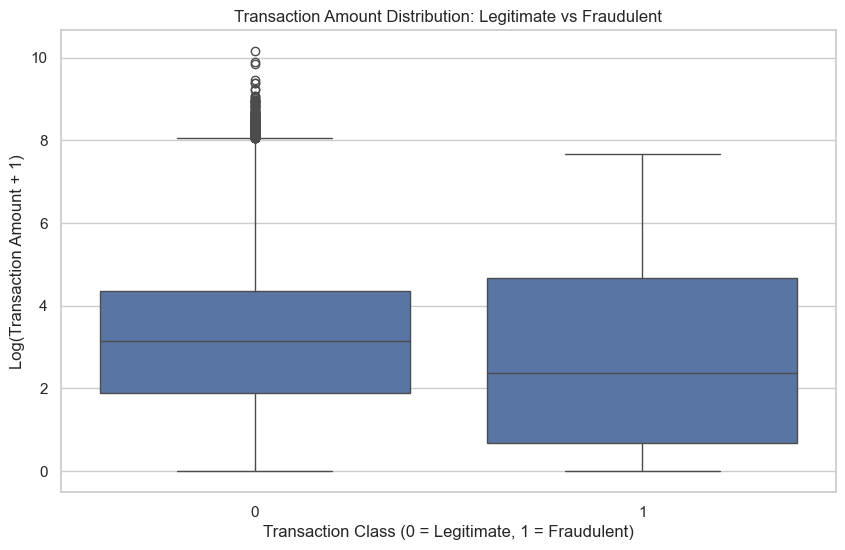

```python
plt.figure(figsize=(10, 6))

sns.boxplot(
    data=df,
    x="Class",
    y="Log_Amount"
)

plt.title("Transaction Amount Distribution: Legitimate vs Fraudulent")
plt.xlabel("Transaction Class (0 = Legitimate, 1 = Fraudulent)")
plt.ylabel("Log(Transaction Amount + 1)")

plt.savefig(
    "Visualizations/transaction_amount_distribution_by_fraud_class.png",
    dpi=300,
    bbox_inches="tight"
)

plt.show()
```

## Interpretation

Transaction amounts show different distributions across legitimate and fraudulent transactions. The median transaction amount is lower for fraudulent transactions, while the fraudulent class exhibits a wider interquartile range. However, substantial overlap exists between the two distributions, indicating that transaction amount alone is unlikely to reliably distinguish fraudulent from legitimate transactions. The presence of numerous high-value legitimate transactions also demonstrates that large transaction amounts should not automatically be treated as evidence of fraud. Transaction amount may therefore be more useful as one feature within a broader fraud-detection framework rather than as a standalone rule.

```python
amount_99th_percentile = df["Amount"].quantile(0.99)

print(
    f"99th percentile transaction amount: "
    f"${amount_99th_percentile:,.2f}"
)
```

```
99th percentile transaction amount: $1,018.97
```

```python
df["High_Value"] = (
    df["Amount"] >= amount_99th_percentile
).astype(int)
```

```python
fraud_rate_by_value = (
    df.groupby("High_Value")["Class"]
    .agg(["count", "sum", "mean"])
)

fraud_rate_by_value
```

| High_Value | count | sum | mean |
| --- | --- | --- | --- |
| 0 | 280888 | 464 | 0.001652 |
| 1 | 2838 | 9 | 0.003171 |

```python
fraud_rate_by_value.columns = [
    "Transactions",
    "Fraud_Count",
    "Fraud_Rate"
]

fraud_rate_by_value["Fraud_Rate"] *= 100

fraud_rate_by_value
```

| High_Value | Transactions | Fraud_Count | Fraud_Rate |
| --- | --- | --- | --- |
| 0 | 280888 | 464 | 0.165190 |
| 1 | 2838 | 9 | 0.317125 |

```python
fraud_rate_by_hour = (
    df.groupby("Hour")["Class"]
    .agg(
        Transactions="count",
        Fraud_Count="sum",
        Fraud_Rate="mean"
    )
)

fraud_rate_by_hour["Fraud_Rate"] *= 100

fraud_rate_by_hour
```

| Hour | Transactions | Fraud_Count | Fraud_Rate |
| --- | --- | --- | --- |
| 0 | 7647 | 6 | 0.078462 |
| 1 | 4208 | 10 | 0.237643 |
| 2 | 3308 | 48 | 1.451028 |
| 3 | 3487 | 17 | 0.487525 |
| 4 | 2204 | 23 | 1.043557 |
| 5 | 2988 | 11 | 0.368139 |
| 6 | 4082 | 9 | 0.220480 |
| 7 | 7233 | 23 | 0.317987 |
| 8 | 10232 | 9 | 0.087959 |
| 9 | 15767 | 16 | 0.101478 |
| 10 | 16548 | 8 | 0.048344 |
| 11 | 16781 | 53 | 0.315833 |
| 12 | 15378 | 17 | 0.110548 |
| 13 | 15323 | 17 | 0.110944 |
| 14 | 16520 | 23 | 0.139225 |
| 15 | 16374 | 26 | 0.158788 |
| 16 | 16396 | 22 | 0.134179 |
| 17 | 16130 | 28 | 0.173590 |
| 18 | 16959 | 28 | 0.165104 |
| 19 | 15566 | 19 | 0.122061 |
| 20 | 16705 | 18 | 0.107752 |
| 21 | 17629 | 16 | 0.090760 |
| 22 | 15378 | 9 | 0.058525 |
| 23 | 10883 | 17 | 0.156207 |

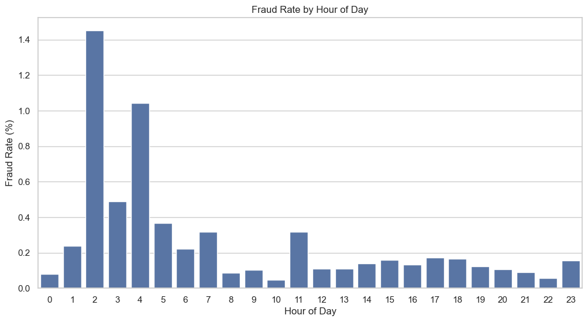

```python
plt.figure(figsize=(12, 6))

sns.barplot(
    data=fraud_rate_by_hour.reset_index(),
    x="Hour",
    y="Fraud_Rate"
)

plt.title("Fraud Rate by Hour of Day")
plt.xlabel("Hour of Day")
plt.ylabel("Fraud Rate (%)")

plt.savefig(
    "Visualizations/fraud_rate_by_hour_python.png",
    dpi=300,
    bbox_inches="tight"
)


plt.show()
```

```python
early_morning_analysis = (
    df.groupby("Is_Early_Morning")["Class"]
    .agg(
        Transactions="count",
        Fraud_Count="sum",
        Fraud_Rate="mean"
    )
)

early_morning_analysis["Fraud_Rate"] *= 100

early_morning_analysis
```

| Is_Early_Morning | Transactions | Fraud_Count | Fraud_Rate |
| --- | --- | --- | --- |
| 0 | 259884 | 358 | 0.137754 |
| 1 | 23842 | 115 | 0.482342 |

```python
early_rate = early_morning_analysis.loc[1, "Fraud_Rate"]
other_rate = early_morning_analysis.loc[0, "Fraud_Rate"]

relative_risk = early_rate / other_rate

print(f"Early-morning fraud rate: {early_rate:.4f}%")
print(f"Other-hours fraud rate: {other_rate:.4f}%")
print(f"Relative risk: {relative_risk:.2f}x")
```

```
Early-morning fraud rate: 0.4823%
Other-hours fraud rate: 0.1378%
Relative risk: 3.50x
```

### Early-Morning Fraud Pattern

Transactions occurring between 00:00 and 05:59 show a higher observed fraud rate than transactions occurring during other hours.

- Early-morning transactions: **0.4823% fraud rate**
- Other transactions: **0.1378% fraud rate**

The early-morning fraud rate is approximately **3.5 times higher** than the rate observed during other hours.

This suggests that transaction timing may be a useful risk indicator for fraud monitoring. However, time of day should not be treated as a standalone fraud rule because most early-morning transactions are still legitimate.

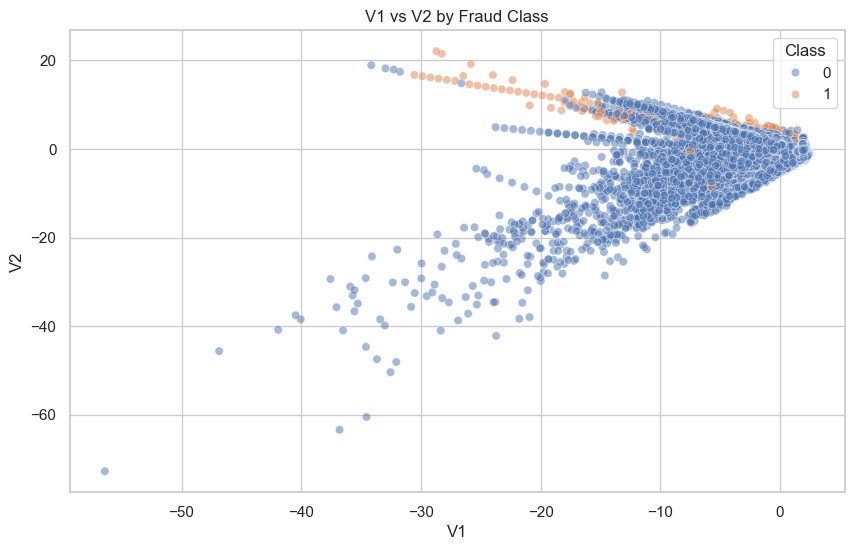

```python
plt.figure(figsize=(10, 6))

sns.scatterplot(
    data=df,
    x="V1",
    y="V2",
    hue="Class",
    alpha=0.5
)

plt.title("V1 vs V2 by Fraud Class")
plt.xlabel("V1")
plt.ylabel("V2")

plt.savefig(
    "Visualizations/v1_vs_v2_by_fraud_class.png",
    dpi=300,
    bbox_inches="tight"
)

plt.show()
```

## Interpretation

The scatter plot shows some class-specific structure across the PCA-transformed features V1 and V2. Fraudulent transactions appear in several regions of the feature space where legitimate transactions are less concentrated. However, substantial overlap exists between the two classes, indicating that V1 and V2 alone do not provide a clear separation between fraudulent and legitimate transactions. This supports using multiple transaction features rather than relying on a simple rule based on these two variables.

## SQL Analysis

### Question 1

Are high-value transactions disproportionately associated with fraud?

### Question 2

Are transactions occurring during early-morning hours associated with higher fraud rates?

### Question 3

Are there periods with unusually high transaction volumes?

```python
# Creating a temporary in-memory SQLite database and loading the DataFrame into it for SQL queries.
conn = sqlite3.connect(":memory:")

df.to_sql(
    "transactions",
    conn,
    index=False,
    if_exists="replace"
)
```

```
283726
```

```python
#Checking the database connection and the data in the transactions table
select_query = """
SELECT *
FROM transactions
LIMIT 5;
"""
select_result = pd.read_sql_query(select_query, conn)
select_result
```

|  | Time | V1 | V2 | V3 | V4 | V5 | V6 | V7 | V8 | V9 | V10 | V11 | V12 | V13 | V14 | V15 | V16 | V17 | V18 | V19 | V20 | V21 | V22 | V23 | V24 | V25 | V26 | V27 | V28 | … |
| --- | --- | --- | --- | --- | --- | --- | --- | --- | --- | --- | --- | --- | --- | --- | --- | --- | --- | --- | --- | --- | --- | --- | --- | --- | --- | --- | --- | --- | --- | --- |
| 0 | 0.0 | -1.359807 | -0.072781 | 2.536347 | 1.378155 | -0.338321 | 0.462388 | 0.239599 | 0.098698 | 0.363787 | 0.090794 | -0.551600 | -0.617801 | -0.991390 | -0.311169 | 1.468177 | -0.470401 | 0.207971 | 0.025791 | 0.403993 | 0.251412 | -0.018307 | 0.277838 | -0.110474 | 0.066928 | 0.128539 | -0.189115 | 0.133558 | -0.021053 | … |
| 1 | 0.0 | 1.191857 | 0.266151 | 0.166480 | 0.448154 | 0.060018 | -0.082361 | -0.078803 | 0.085102 | -0.255425 | -0.166974 | 1.612727 | 1.065235 | 0.489095 | -0.143772 | 0.635558 | 0.463917 | -0.114805 | -0.183361 | -0.145783 | -0.069083 | -0.225775 | -0.638672 | 0.101288 | -0.339846 | 0.167170 | 0.125895 | -0.008983 | 0.014724 | … |
| 2 | 1.0 | -1.358354 | -1.340163 | 1.773209 | 0.379780 | -0.503198 | 1.800499 | 0.791461 | 0.247676 | -1.514654 | 0.207643 | 0.624501 | 0.066084 | 0.717293 | -0.165946 | 2.345865 | -2.890083 | 1.109969 | -0.121359 | -2.261857 | 0.524980 | 0.247998 | 0.771679 | 0.909412 | -0.689281 | -0.327642 | -0.139097 | -0.055353 | -0.059752 | … |
| 3 | 1.0 | -0.966272 | -0.185226 | 1.792993 | -0.863291 | -0.010309 | 1.247203 | 0.237609 | 0.377436 | -1.387024 | -0.054952 | -0.226487 | 0.178228 | 0.507757 | -0.287924 | -0.631418 | -1.059647 | -0.684093 | 1.965775 | -1.232622 | -0.208038 | -0.108300 | 0.005274 | -0.190321 | -1.175575 | 0.647376 | -0.221929 | 0.062723 | 0.061458 | … |
| 4 | 2.0 | -1.158233 | 0.877737 | 1.548718 | 0.403034 | -0.407193 | 0.095921 | 0.592941 | -0.270533 | 0.817739 | 0.753074 | -0.822843 | 0.538196 | 1.345852 | -1.119670 | 0.175121 | -0.451449 | -0.237033 | -0.038195 | 0.803487 | 0.408542 | -0.009431 | 0.798278 | -0.137458 | 0.141267 | -0.206010 | 0.502292 | 0.219422 | 0.215153 | … |

```python
# Query for total transactions, fraud count and fraud rate using SQL
query = """
SELECT
    COUNT(*) AS Transactions,
    SUM(Class) AS Fraud_Count,
    AVG(Class) * 100 AS Fraud_Rate
FROM transactions;
"""

result = pd.read_sql_query(query, conn)

result
```

|  | Transactions | Fraud_Count | Fraud_Rate |
| --- | --- | --- | --- |
| 0 | 283726 | 473 | 0.16671 |

### Question 1

**Are high-value transactions disproportionately associated with fraud?**

To investigate this, I define high-value transactions as the top 1% of transactions ranked by transaction amount.

```python
query_q1 = """
WITH ranked_transactions AS (
    SELECT
        Amount,
        Class,
        NTILE(100) OVER (ORDER BY Amount DESC) AS amount_percentile
    FROM transactions
)

SELECT
    CASE
        WHEN amount_percentile = 1 THEN 'Top 1% by Amount'
        ELSE 'Other 99%'
    END AS Transaction_Group,
    COUNT(*) AS Transactions,
    SUM(Class) AS Fraud_Count,
    AVG(Class) * 100 AS Fraud_Rate,
    AVG(Amount) AS Average_Amount
FROM ranked_transactions
GROUP BY Transaction_Group;
"""

q1_result = pd.read_sql_query(query_q1, conn)

q1_result
```

|  | Transaction_Group | Transactions | Fraud_Count | Fraud_Rate | Average_Amount |
| --- | --- | --- | --- | --- | --- |
| 0 | Other 99% | 280888 | 464 | 0.165190 | 70.819139 |
| 1 | Top 1% by Amount | 2838 | 9 | 0.317125 | 1835.713647 |

```python
fraud_rate_ratio = (
    q1_result.loc[
        q1_result["Transaction_Group"] == "Top 1% by Amount",
        "Fraud_Rate"
    ].iloc[0]
    /
    q1_result.loc[
        q1_result["Transaction_Group"] == "Other 99%",
        "Fraud_Rate"
    ].iloc[0]
)

print(f"High-value transactions have a {fraud_rate_ratio:.2f}x higher fraud rate.")
```

```
High-value transactions have a 1.92x higher fraud rate.
```

### Interpretation

The analysis investigates whether high-value transactions are disproportionately associated with fraud. High-value transactions are defined as the top 1% of transactions ranked by transaction amount.

The results show that the **Top 1% by Amount** have a fraud rate of **0.317%**, compared with **0.165%** for the remaining 99% of transactions. This means that the fraud rate among high-value transactions is approximately **1.9 times higher** than among other transactions.

Although the Top 1% contain only **9 fraudulent transactions**, compared with **464 fraudulent transactions** in the remaining 99%, this difference in fraud count is largely driven by the much smaller number of transactions in the Top 1% (2,838 compared with 280,888). Therefore, **fraud rate is a more appropriate metric for comparing the two groups than the absolute fraud count**.

The average transaction amount also shows a substantial difference between the groups. Transactions in the Top 1% have an average amount of approximately **1,835.71**, compared with **70.82** for the remaining 99%. This confirms that the segmentation successfully isolates substantially higher-value transactions.

### Business Insight

The results provide evidence that **high-value transactions are disproportionately associated with fraud**. The approximately **1.9× higher fraud rate** suggests that transaction amount may be a useful indicator of fraud risk.

From a fraud-management perspective, high-value transactions could therefore be considered for **additional monitoring or risk-based controls**. However, transaction amount should not be used as a standalone fraud indicator. Despite their higher relative fraud rate, the Top 1% account for only **9 of the 473 fraudulent transactions** observed in these two groups. The majority of fraud therefore occurs outside the highest-value transactions.

### Conclusion

**High-value transactions show a higher relative fraud risk, but they do not account for the majority of fraud.** Transaction amount may therefore be useful as one component of a broader fraud-risk detection strategy, alongside other transaction and customer-level indicators.

### Question 2

**Are transactions occurring during early-morning hours associated with higher fraud rates?**

To investigate this, I use the transaction `Time` variable to identify the hour in which each transaction occurred. The hour is represented on a 24-hour scale, where 0 represents midnight, 1 represents 1:00 AM and so forth.

I define **early-morning hours as 00:00–05:59 (hours 0–5)** and classify all transactions into two groups:

- **Early Morning:** hours 0–5
- **Other Hours:** hours 6–23

I then compare the number of transactions, fraud count and fraud rate between the two groups. Fraud rate is calculated as the percentage of transactions classified as fraudulent within each time group.

```python
# Query for hourly transactions, fraud count and fraud rate using SQL
query_q2_hourly = """
SELECT
    CAST(strftime('%H', time, 'unixepoch') AS INTEGER) AS Hour,
    COUNT(*) AS Transactions,
    SUM(Class) AS Fraud_Count,
    AVG(Class) * 100 AS Fraud_Rate
FROM transactions
GROUP BY Hour
ORDER BY Hour;
"""

q2_hourly = pd.read_sql_query(query_q2_hourly, conn)

q2_hourly
```

|  | Hour | Transactions | Fraud_Count | Fraud_Rate |
| --- | --- | --- | --- | --- |
| 0 | 0 | 7647 | 6 | 0.078462 |
| 1 | 1 | 4208 | 10 | 0.237643 |
| 2 | 2 | 3308 | 48 | 1.451028 |
| 3 | 3 | 3487 | 17 | 0.487525 |
| 4 | 4 | 2204 | 23 | 1.043557 |
| 5 | 5 | 2988 | 11 | 0.368139 |
| 6 | 6 | 4082 | 9 | 0.220480 |
| 7 | 7 | 7233 | 23 | 0.317987 |
| 8 | 8 | 10232 | 9 | 0.087959 |
| 9 | 9 | 15767 | 16 | 0.101478 |
| 10 | 10 | 16548 | 8 | 0.048344 |
| 11 | 11 | 16781 | 53 | 0.315833 |
| 12 | 12 | 15378 | 17 | 0.110548 |
| 13 | 13 | 15323 | 17 | 0.110944 |
| 14 | 14 | 16520 | 23 | 0.139225 |
| 15 | 15 | 16374 | 26 | 0.158788 |
| 16 | 16 | 16396 | 22 | 0.134179 |
| 17 | 17 | 16130 | 28 | 0.173590 |
| 18 | 18 | 16959 | 28 | 0.165104 |
| 19 | 19 | 15566 | 19 | 0.122061 |
| 20 | 20 | 16705 | 18 | 0.107752 |
| 21 | 21 | 17629 | 16 | 0.090760 |
| 22 | 22 | 15378 | 9 | 0.058525 |
| 23 | 23 | 10883 | 17 | 0.156207 |

```python
# Query for early-morning transactions, fraud count and fraud rate using SQL
query_q2 = """
SELECT
    CASE
        WHEN CAST(strftime('%H', time, 'unixepoch') AS INTEGER)
             BETWEEN 0 AND 5
        THEN 'Early Morning'
        ELSE 'Other Hours'
    END AS Time_Group,

    COUNT(*) AS Transactions,
    SUM(Class) AS Fraud_Count,
    AVG(Class) * 100 AS Fraud_Rate

FROM transactions

GROUP BY Time_Group;
"""

q2_result = pd.read_sql_query(query_q2, conn)

q2_result
```

|  | Time_Group | Transactions | Fraud_Count | Fraud_Rate |
| --- | --- | --- | --- | --- |
| 0 | Early Morning | 23842 | 115 | 0.482342 |
| 1 | Other Hours | 259884 | 358 | 0.137754 |

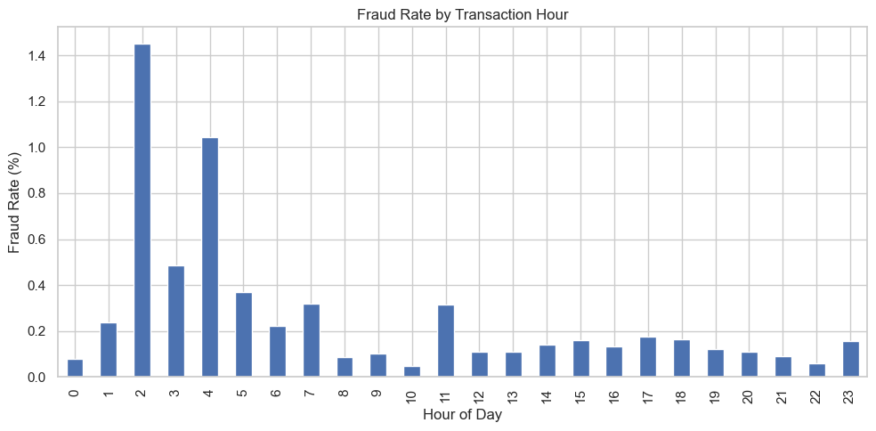

```python
ax = q2_hourly.plot(
    x="Hour",
    y="Fraud_Rate",
    kind="bar",
    figsize=(10, 5),
    legend=False
)

ax.set_title("Fraud Rate by Transaction Hour")
ax.set_xlabel("Hour of Day")
ax.set_ylabel("Fraud Rate (%)")

plt.tight_layout()

plt.savefig(
    "Visualizations/fraud_rate_by_hour.png",
    dpi=300,
    bbox_inches="tight"
)

plt.show()
```

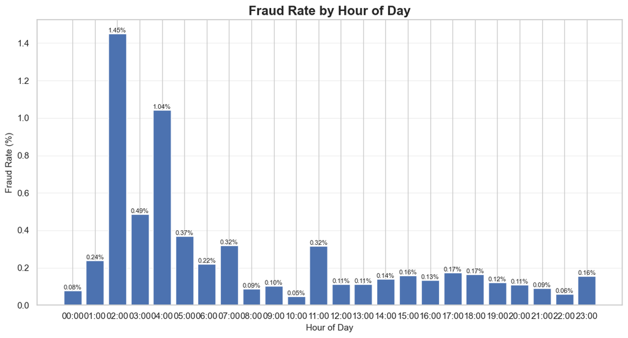

```python
fig, ax = plt.subplots(figsize=(11, 6))

bars = ax.bar(
    q2_hourly["Hour"],
    q2_hourly["Fraud_Rate"]
)

ax.set_title(
    "Fraud Rate by Hour of Day",
    fontsize=16,
    fontweight="bold"
)

ax.set_xlabel("Hour of Day", fontsize=11)
ax.set_ylabel("Fraud Rate (%)", fontsize=11)

ax.set_xticks(range(24))
ax.set_xticklabels([f"{hour:02d}:00" for hour in range(24)])

ax.grid(
    axis="y",
    alpha=0.3
)

# Add fraud-rate values above each bar
for bar, rate in zip(bars, q2_hourly["Fraud_Rate"]):
    ax.text(
        bar.get_x() + bar.get_width() / 2,
        bar.get_height(),
        f"{rate:.2f}%",
        ha="center",
        va="bottom",
        fontsize=8
    )

plt.tight_layout()

plt.savefig(
    "Visualizations/fraud_rate_by_hour_stakeholders.png",
    dpi=300,
    bbox_inches="tight"
)

plt.show()
```

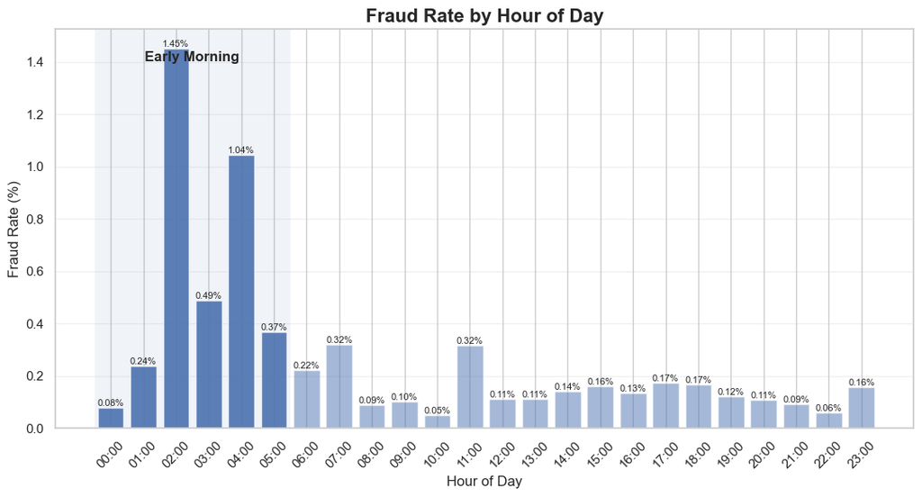

```python
fig, ax = plt.subplots(figsize=(11, 6))

# Create bars
bars = ax.bar(
    q2_hourly["Hour"],
    q2_hourly["Fraud_Rate"]
)

# Highlight early-morning hours
for i, bar in enumerate(bars):
    if q2_hourly.loc[i, "Hour"] <= 5:
        bar.set_alpha(0.9)
    else:
        bar.set_alpha(0.5)

ax.set_title(
    "Fraud Rate by Hour of Day",
    fontsize=16,
    fontweight="bold"
)

ax.set_xlabel("Hour of Day")
ax.set_ylabel("Fraud Rate (%)")

ax.set_xticks(range(24))
ax.set_xticklabels(
    [f"{hour:02d}:00" for hour in range(24)],
    rotation=45
)

ax.grid(
    axis="y",
    alpha=0.3
)

# Add values
for bar, rate in zip(bars, q2_hourly["Fraud_Rate"]):
    ax.text(
        bar.get_x() + bar.get_width() / 2,
        bar.get_height(),
        f"{rate:.2f}%",
        ha="center",
        va="bottom",
        fontsize=8
    )

# Highlight the early-morning region
ax.axvspan(
    -0.5,
    5.5,
    alpha=0.08
)

ax.text(
    2.5,
    ax.get_ylim()[1] * 0.92,
    "Early Morning",
    ha="center",
    fontweight="bold"
)

plt.tight_layout()

plt.savefig(
    "Visualizations/fraud_rate_by_hour_early_morning_highlighted.png",
    dpi=300,
    bbox_inches="tight"
)

plt.show()
```

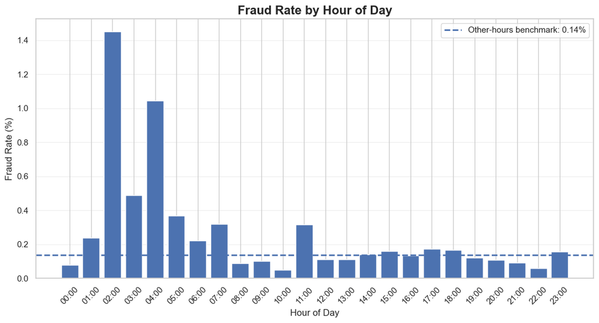

```python
other_hours_rate = (
    q2_result.loc[
        q2_result["Time_Group"] == "Other Hours",
        "Fraud_Rate"
    ].iloc[0]
)

fig, ax = plt.subplots(figsize=(11, 6))

bars = ax.bar(
    q2_hourly["Hour"],
    q2_hourly["Fraud_Rate"]
)

ax.axhline(
    other_hours_rate,
    linestyle="--",
    linewidth=2,
    label=f"Other-hours benchmark: {other_hours_rate:.2f}%"
)

ax.set_title(
    "Fraud Rate by Hour of Day",
    fontsize=16,
    fontweight="bold"
)

ax.set_xlabel("Hour of Day")
ax.set_ylabel("Fraud Rate (%)")

ax.set_xticks(range(24))
ax.set_xticklabels(
    [f"{hour:02d}:00" for hour in range(24)],
    rotation=45
)

ax.legend()

ax.grid(
    axis="y",
    alpha=0.3
)

plt.tight_layout()

plt.savefig(
    "Visualizations/fraud_rate_by_hour_benchmark.png",
    dpi=300,
    bbox_inches="tight"
)

plt.show()
```

### Interpretation

The results show a substantial difference in fraud rates between early-morning transactions and transactions occurring during other hours.

Early-morning transactions have a fraud rate of **0.482%**, compared with **0.138%** for transactions occurring during other hours. This means that the fraud rate during the early morning is approximately **3.5 times higher** than during other hours.

There are **115 fraudulent transactions among 23,842 early-morning transactions**, compared with **358 fraudulent transactions among 259,884 transactions during other hours**.

Although the absolute number of fraudulent transactions is higher during other hours, this is largely because the majority of transactions occur during those hours. The fraud rate provides a more appropriate comparison because it accounts for the different number of transactions in each group.

### Business Insight

The results provide evidence that **early-morning transactions are disproportionately associated with fraud**. The approximately **3.5× higher fraud rate** suggests that time of day may be a useful indicator of fraud risk.

From a fraud-detection perspective, transactions occurring during early-morning hours could therefore be considered for **additional monitoring or risk-based controls**, particularly when combined with other risk indicators.

However, time of day should not be treated as a standalone fraud indicator. Most fraudulent transactions in this dataset still occur during other hours, so using early-morning activity alone would miss a substantial proportion of fraud.

### Conclusion

**Early-morning transactions have a substantially higher fraud rate than transactions occurring during other hours, with a fraud rate approximately 3.5 times higher. This suggests that transaction time may be a useful feature for identifying potentially higher-risk transactions.**

### Question 3

**Are there periods with unusually high transaction volumes?**

To investigate this, I aggregate transactions into consecutive one-hour blocks based on the `Time` variable. For each hourly block, I calculate the total number of transactions, fraud count and fraud rate.

I then calculate the **mean** and **standard deviation** of hourly transaction volume across all hourly blocks. I classified the busiest 5% of hourly periods as unusually high transaction activity.

Finally, I classify each hourly block as either **Normal** or **Unusually High** based on this threshold.

This approach identifies periods where transaction activity is substantially higher than the typical hourly level.

```python
query_q3 = """
WITH hourly_activity AS (
    SELECT
        CAST(time / 3600 AS INTEGER) AS Hour_Block,
        COUNT(*) AS Transaction_Count,
        SUM(Class) AS Fraud_Count,
        AVG(Class) * 100 AS Fraud_Rate
    FROM transactions
    GROUP BY Hour_Block
)

SELECT
    Hour_Block,
    Transaction_Count,
    Fraud_Count,
    Fraud_Rate
FROM hourly_activity
ORDER BY Transaction_Count DESC;
"""

q3_result = pd.read_sql_query(query_q3, conn)

q3_result.head(10)
```

|  | Hour_Block | Transaction_Count | Fraud_Count | Fraud_Rate |
| --- | --- | --- | --- | --- |
| 0 | 21 | 9875 | 14 | 0.141772 |
| 1 | 20 | 8946 | 8 | 0.089425 |
| 2 | 22 | 8943 | 3 | 0.033546 |
| 3 | 40 | 8626 | 8 | 0.092743 |
| 4 | 39 | 8567 | 12 | 0.140072 |
| 5 | 18 | 8548 | 10 | 0.116986 |
| 6 | 38 | 8508 | 10 | 0.117536 |
| 7 | 11 | 8474 | 43 | 0.507435 |
| 8 | 42 | 8411 | 18 | 0.214005 |
| 9 | 35 | 8307 | 10 | 0.120380 |

```python
query_q3 = """
SELECT
    CAST(time / 3600 AS INTEGER) AS Hour_Block,
    COUNT(*) AS Transaction_Count,
    SUM(Class) AS Fraud_Count,
    AVG(Class) * 100 AS Fraud_Rate
FROM transactions
GROUP BY Hour_Block
ORDER BY Transaction_Count DESC;
"""

q3_result = pd.read_sql_query(query_q3, conn)

# Step 2: Calculate the average and standard deviation
# of hourly transaction volume in Python

mean_transactions = q3_result["Transaction_Count"].mean()
std_transactions = q3_result["Transaction_Count"].std()
q3_threshold_95 = q3_result["Transaction_Count"].quantile(0.95)

print(f"95th percentile threshold: {q3_threshold_95:.2f}")


# Step 3: Classify each hourly period

q3_result["Activity_Level_95"] = np.where(
    q3_result["Transaction_Count"] > q3_threshold_95,
    "Unusually High",
    "Normal"
)

# Step 5: Add the statistical benchmarks to the results

q3_result["Mean_Transactions"] = mean_transactions
q3_result["Std_Transactions"] = std_transactions
q3_result["Threshold"] = q3_threshold_95


# Step 6: Display the periods with the highest activity

unusual_periods_95 = q3_result[
    q3_result["Activity_Level_95"] == "Unusually High"
].sort_values(
    "Transaction_Count",
    ascending=False
)

unusual_periods_95
```

```
95th percentile threshold: 8832.05
```

|  | Hour_Block | Transaction_Count | Fraud_Count | Fraud_Rate | Activity_Level_95 | Mean_Transactions | Std_Transactions | Threshold |
| --- | --- | --- | --- | --- | --- | --- | --- | --- |
| 0 | 21 | 9875 | 14 | 0.141772 | Unusually High | 5910.958333 | 2860.0319 | 8832.05 |
| 1 | 20 | 8946 | 8 | 0.089425 | Unusually High | 5910.958333 | 2860.0319 | 8832.05 |
| 2 | 22 | 8943 | 3 | 0.033546 | Unusually High | 5910.958333 | 2860.0319 | 8832.05 |

### Threshold Selection

Rather than relying solely on a mean + 2 standard deviation threshold, I use the **95th percentile of hourly transaction volume** to identify unusually high activity.

This approach is appropriate because it does not require transaction volume to follow a normal distribution and provides an intuitive business interpretation: the highest 5% of hourly periods are considered unusually active.

A percentile-based threshold is also less sensitive to extreme observations than a mean-based threshold, making it useful for identifying unusually high transaction activity in potentially skewed transaction-volume data.

Therefore, an hourly period is classified as **Unusually High** when its transaction volume exceeds the 95th percentile of observed hourly transaction volume.

```python
activity_summary = (
    q3_result
    .groupby("Activity_Level_95")
    .agg(
        Periods=("Hour_Block", "count"),
        Total_Transactions=("Transaction_Count", "sum"),
        Total_Fraud=("Fraud_Count", "sum"),
        Average_Fraud_Rate=("Fraud_Rate", "mean")
    )
    .reset_index()
)

activity_summary
```

|  | Activity_Level_95 | Periods | Total_Transactions | Total_Fraud | Average_Fraud_Rate |
| --- | --- | --- | --- | --- | --- |
| 0 | Normal | 45 | 255962 | 448 | 0.271593 |
| 1 | Unusually High | 3 | 27764 | 25 | 0.088248 |

### Interpretation

To identify unusually high transaction activity, I defined the **95th percentile of hourly transaction volume** as the threshold. This produced a threshold of **8,832 transactions per one-hour period**, meaning that hourly periods with more than 8,832 transactions were classified as unusually high.

Using this definition, **3 out of 48 hourly periods** were classified as unusually high:

- Hour Block 21: **9,875 transactions**
- Hour Block 20: **8,946 transactions**
- Hour Block 22: **8,943 transactions**

Together, these unusually high-activity periods accounted for **27,764 transactions** and **25 fraudulent transactions**.

### Fraud Comparison

Interestingly, the unusually high transaction-volume periods did **not** have higher fraud rates than normal periods.

The average fraud rate during normal periods was **0.272%**, compared with only **0.088%** during unusually high-activity periods.

This means that the average fraud rate during unusually high-activity periods was approximately **68% lower** than during normal periods:

**0.088% / 0.272% ≈ 0.32**

Therefore, although these periods experienced substantially higher transaction volumes, the elevated activity was **not accompanied by an elevated fraud rate** in this dataset.

### Business Insight

The analysis suggests that **high transaction volume alone is not a strong indicator of increased fraud risk**. The busiest periods generated more transactions, but their fraud rate was lower than that of normal periods.

This is an important finding from a fraud-management perspective. A fraud monitoring system that automatically treats transaction-volume spikes as evidence of increased fraud risk could generate unnecessary alerts or investigations.

Instead, transaction-volume anomalies should be considered alongside other fraud indicators, such as transaction amount, time of day, customer behavior, transaction frequency, and other relevant risk features.

### Conclusion

**There are periods of unusually high transaction activity, but these periods are not associated with higher fraud rates.** Using the 95th percentile as the activity threshold identified 3 unusually high-volume periods, with an average fraud rate of **0.088%**, compared with **0.272%** during normal periods.

Therefore, the results do **not** support the hypothesis that unusually high transaction volume is associated with increased fraud in this dataset. Transaction volume may still be useful for monitoring operational activity, but it should not be treated as a standalone indicator of fraud risk.

## Isolation Forest — Anomaly Detection

## Objective

The previous exploratory analyses identified several transaction characteristics that may be associated with fraudulent activity.

The next step is to determine whether these characteristics can be combined to identify transactions that appear unusual relative to the wider transaction population.

For this purpose, I use **Isolation Forest**, an unsupervised anomaly detection algorithm.

The objective is not to classify fraud directly, but to identify transactions with unusual characteristics and then assess how well those anomalies correspond to known fraudulent transactions.

### Business objective

From a business perspective, the goal is to determine whether anomaly detection can help prioritize potentially suspicious transactions for further investigation.

## Feature Selection

The model uses 31 features.

These consist of:

- `V1`–`V28`: the 28 anonymized numerical transaction features in the original dataset.
- `Log_Amount`: a logarithmic transformation of transaction amount.
- `Hour`: the transaction hour derived from transaction time.
- `Is_Early_Morning`: an indicator identifying transactions occurring between midnight and 5:00 AM.

The feature set therefore combines the original transaction characteristics with engineered variables motivated by the earlier exploratory analysis.

This allows the anomaly detector to evaluate unusual transaction profiles using both the underlying anonymized features and the business-relevant transaction characteristics.

```python
feature_columns = [
    col for col in df.columns
    if col.startswith("V")
]

feature_columns += [
    "Log_Amount",
    "Hour",
    "Is_Early_Morning"
]

X = df[feature_columns]
y = df["Class"]

print("Number of model features:", len(feature_columns))
print("Number of observations:", len(X))

X.head()
```

```
Number of model features: 31
Number of observations: 283726
```

|  | V1 | V2 | V3 | V4 | V5 | V6 | V7 | V8 | V9 | V10 | V11 | V12 | V13 | V14 | V15 | V16 | V17 | V18 | V19 | V20 | V21 | V22 | V23 | V24 | V25 | V26 | V27 | V28 | Log_Amount | … |
| --- | --- | --- | --- | --- | --- | --- | --- | --- | --- | --- | --- | --- | --- | --- | --- | --- | --- | --- | --- | --- | --- | --- | --- | --- | --- | --- | --- | --- | --- | --- |
| 0 | -1.359807 | -0.072781 | 2.536347 | 1.378155 | -0.338321 | 0.462388 | 0.239599 | 0.098698 | 0.363787 | 0.090794 | -0.551600 | -0.617801 | -0.991390 | -0.311169 | 1.468177 | -0.470401 | 0.207971 | 0.025791 | 0.403993 | 0.251412 | -0.018307 | 0.277838 | -0.110474 | 0.066928 | 0.128539 | -0.189115 | 0.133558 | -0.021053 | 5.014760 | … |
| 1 | 1.191857 | 0.266151 | 0.166480 | 0.448154 | 0.060018 | -0.082361 | -0.078803 | 0.085102 | -0.255425 | -0.166974 | 1.612727 | 1.065235 | 0.489095 | -0.143772 | 0.635558 | 0.463917 | -0.114805 | -0.183361 | -0.145783 | -0.069083 | -0.225775 | -0.638672 | 0.101288 | -0.339846 | 0.167170 | 0.125895 | -0.008983 | 0.014724 | 1.305626 | … |
| 2 | -1.358354 | -1.340163 | 1.773209 | 0.379780 | -0.503198 | 1.800499 | 0.791461 | 0.247676 | -1.514654 | 0.207643 | 0.624501 | 0.066084 | 0.717293 | -0.165946 | 2.345865 | -2.890083 | 1.109969 | -0.121359 | -2.261857 | 0.524980 | 0.247998 | 0.771679 | 0.909412 | -0.689281 | -0.327642 | -0.139097 | -0.055353 | -0.059752 | 5.939276 | … |
| 3 | -0.966272 | -0.185226 | 1.792993 | -0.863291 | -0.010309 | 1.247203 | 0.237609 | 0.377436 | -1.387024 | -0.054952 | -0.226487 | 0.178228 | 0.507757 | -0.287924 | -0.631418 | -1.059647 | -0.684093 | 1.965775 | -1.232622 | -0.208038 | -0.108300 | 0.005274 | -0.190321 | -1.175575 | 0.647376 | -0.221929 | 0.062723 | 0.061458 | 4.824306 | … |
| 4 | -1.158233 | 0.877737 | 1.548718 | 0.403034 | -0.407193 | 0.095921 | 0.592941 | -0.270533 | 0.817739 | 0.753074 | -0.822843 | 0.538196 | 1.345852 | -1.119670 | 0.175121 | -0.451449 | -0.237033 | -0.038195 | 0.803487 | 0.408542 | -0.009431 | 0.798278 | -0.137458 | 0.141267 | -0.206010 | 0.502292 | 0.219422 | 0.215153 | 4.262539 | … |

### Why this matters

From a business perspective, feature selection should not be arbitrary.

The model incorporates:

1. **Anonymized transaction characteristics** — to capture unusual transaction patterns.
2. **Transaction amount** — because unusually large transactions may represent increased financial exposure.
3. **Time of day** — because transaction timing may provide additional behavioral information.
4. **Early-morning activity** — because the exploratory analysis identified this as a potentially relevant risk indicator.

This creates a connection between the earlier exploratory analysis and the predictive/anomaly detection stage of the project.

## Creating an Unseen Test Set

To obtain a more defensible estimate of model performance, the data is divided into training and testing subsets.

The split produces:

- **198,608 training observations (70%)**
- **85,118 testing observations (30%)**

Stratification is applied to preserve the proportion of fraudulent transactions in both datasets.

This is particularly important because fraud is extremely rare in the dataset.

The fraud rate is approximately **0.167% in both the training and testing sets**, indicating that the stratified split has preserved the original class distribution.

The model will be trained only on the training observations and evaluated on the previously unseen test observations.

```python
from sklearn.model_selection import train_test_split

X_train, X_test, y_train, y_test = train_test_split(
    X,
    y,
    test_size=0.30,
    random_state=42,
    stratify=y
)

print("Training observations:", len(X_train))
print("Testing observations:", len(X_test))

print("\nTraining fraud rate:", f"{y_train.mean():.4%}")
print("\nTesting fraud rate: ", f"{y_test.mean():.4%}")
```

```
Training observations: 198608
Testing observations: 85118

Training fraud rate: 0.1667%

Testing fraud rate:  0.1668%
```

### Interpretation

The very similar fraud rates in the two datasets indicate that the train/test split has maintained the underlying class imbalance.

This gives us a more credible evaluation than measuring performance on the same observations used to fit the model.

# Training the Isolation Forest

## Setting the Contamination Parameter

The training fraud rate is approximately **0.1667%**.

This value is used as the Isolation Forest contamination parameter.

The contamination parameter represents the expected proportion of observations that the algorithm will treat as anomalous.

Therefore, the model is configured with an expected anomaly proportion of approximately **0.167%**, corresponding to the observed fraud prevalence in the training data.

### Important modeling assumption

This does not mean that Isolation Forest is learning which transactions are fraudulent.

Isolation Forest remains an **unsupervised anomaly detection algorithm**.

Instead, the known training fraud prevalence is being used as a practical assumption about how many observations should be considered anomalous.

The resulting anomaly predictions are then evaluated against the known fraud labels in the unseen test set.

```python
training_fraud_rate = y_train.mean()

print(
    f"Training fraud rate: "
    f"{training_fraud_rate:.4%}"
)

from sklearn.ensemble import IsolationForest

model = IsolationForest(
    contamination=training_fraud_rate,
    random_state=42,
    n_estimators=200,
    n_jobs=-1
)

model.fit(X_train)
```

```
Training fraud rate: 0.1667%
```

```
IsolationForest(contamination=0.0016665995327479256, n_estimators=200,
                n_jobs=-1, random_state=42)
```

### Model configuration

The model uses 200 trees (`n_estimators=200`) to provide a more stable estimate of transaction abnormality.

A fixed `random_state` ensures that the results are reproducible.

The model is trained exclusively on the training observations. The test observations remain unseen until the evaluation stage.

# Generate Anomaly Predictions

Isolation Forest produces:

- `1` → normal observation
- `-1` → anomalous observation

The predictions are converted into the fraud-analysis convention:

- `0` → not flagged as anomalous
- `1` → flagged as anomalous

The model flagged **146 of the 85,118 test transactions** as anomalous.

This represents an anomaly rate of approximately **0.172%**, which is very close to the contamination level specified during model training.

Importantly, an anomaly flag does not mean that the transaction is confirmed fraudulent.

It means that the transaction appears unusual according to the patterns identified by the Isolation Forest and may therefore warrant additional investigation.

```python
predictions = model.predict(X_test)

predictions = np.where(
    predictions == -1,
    1,
    0
)

print("Predicted anomalies:", predictions.sum())
print("Predicted anomaly rate:", f"{predictions.mean():.4%}")
```

```
Predicted anomalies: 146
Predicted anomaly rate: 0.1715%
```

### Initial Business Interpretation

The model generates a relatively small investigation population: only 146 transactions out of 85,118 test transactions were flagged.

From an operational perspective, this is attractive because it limits the number of transactions requiring manual review.

However, the usefulness of this investigation queue depends on how many of those flagged transactions are actually fraudulent.

This is evaluated using precision, recall and the confusion matrix in the next section.

# Model Evaluation

## Evaluating anomaly detection against known fraud

Although Isolation Forest is an unsupervised model, this dataset contains known fraud labels.

This allows us to compare the anomaly flags generated by the model against confirmed fraudulent transactions.

Because fraud is highly imbalanced, accuracy is not the primary performance measure.

Instead, the analysis focuses on:

### Precision

Of all transactions flagged as anomalous, what proportion were actually fraudulent?

This is particularly relevant to the investigation team because low precision could result in a large number of legitimate transactions being sent for review.

### Recall

Of all confirmed fraudulent transactions, what proportion were successfully flagged?

Recall measures the model's ability to identify fraudulent activity.

### F1-score

The F1-score provides a balance between precision and recall.

This is useful when both missed fraud and unnecessary investigations have business consequences.

```python
from sklearn.metrics import (
    confusion_matrix,
    classification_report,
    precision_score,
    recall_score,
    f1_score
)

cm = confusion_matrix(y_test, predictions)

cm
```

```
array([[84860,   116],
       [  112,    30]], dtype=int64)
```

## Confusion Matrix Results

The model produced the following results on the 85,118 test transactions:

- **30 fraudulent transactions were correctly flagged**.
- **112 fraudulent transactions were missed**.
- **116 legitimate transactions were incorrectly flagged**.
- **84,860 legitimate transactions were correctly treated as non-anomalous**.

The results highlight an important trade-off.

The model successfully identifies some fraudulent transactions while keeping the overall number of flagged transactions very small.

However, it also misses a substantial proportion of the confirmed fraudulent transactions.

```python
print(
    classification_report(
        y_test,
        predictions,
        target_names=["Legitimate", "Fraud"]
    )
)
```

```
              precision    recall  f1-score   support

  Legitimate       1.00      1.00      1.00     84976
       Fraud       0.21      0.21      0.21       142

    accuracy                           1.00     85118
   macro avg       0.60      0.60      0.60     85118
weighted avg       1.00      1.00      1.00     85118
```

```python
precision = precision_score(y_test, predictions)
recall = recall_score(y_test, predictions)
f1 = f1_score(y_test, predictions)

print(f"Precision: {precision:.2%}")
print(f"Recall:    {recall:.2%}")
print(f"F1-score:  {f1:.2%}")
```

[output not shown]

## Model Performance

The Isolation Forest achieved:

- **Precision: 20.55%**
- **Recall: 21.13%**
- **F1-score: 20.83%**

### Precision — Investigation Efficiency

A precision of **20.55%** means that approximately one in five transactions flagged by the model was actually fraudulent.

In practical terms, for every 100 transactions sent to an investigation queue, approximately 21 would be expected to be confirmed as fraud based on this test-set performance, while the remaining transactions would be legitimate.

This indicates that the model provides some fraud signal, but the investigation queue would still contain a substantial number of false positives.

### Recall — Fraud Detection Coverage

A recall of **21.13%** means that the model identified approximately one in five confirmed fraudulent transactions in the test set.

Conversely, approximately **78.87% of confirmed fraud was not detected** by the anomaly detector.

This is a significant limitation if the objective is to maximize fraud detection coverage.

### F1-score

The F1-score of **20.83%** reflects the relatively weak balance between precision and recall.

Overall, the results suggest that Isolation Forest provides some useful anomaly signal but is not sufficiently effective as a standalone fraud detection solution.

# Business Interpretation

## What Does the Model Tell Us?

The Isolation Forest successfully identifies a small subset of transactions that are statistically unusual.

However, the test-set results show that unusual transaction behavior does not consistently correspond to confirmed fraud.

The model flagged **146 transactions** as anomalous.

Of these:

- **30 were fraudulent**
- **116 were legitimate**

This produces a precision of **20.55%**.

At the same time, the model identified only **30 of the 142 fraudulent transactions** in the test set, producing a recall of **21.13%**.

### What this means for the business

The model can potentially be used as one signal within a broader fraud-monitoring system, but it should not be used as a standalone fraud decisioning mechanism.

Its strongest potential use is **investigation prioritization**.

For example, anomaly detection could be combined with:

- transaction amount,
- transaction timing,
- customer transaction history,
- previous suspicious activity,
- velocity indicators,
- and other fraud-risk signals.

A transaction that is anomalous and simultaneously exhibits several other risk indicators could receive a higher investigation priority.

### Key conclusion

The Isolation Forest provides evidence that some fraudulent transactions exhibit unusual transaction profiles.

However, with a recall of only **21.13%**, the model misses the majority of confirmed fraud.

Therefore, the current model should be treated as a **baseline anomaly detection approach**, rather than a production-ready fraud detection solution.

# Consolidated Risk Indicators

The analysis has identified several potential risk indicators that can be considered when designing a fraud-monitoring framework.

The strength of each indicator should be based on the empirical results from the corresponding analysis.

| Risk Indicator | Evidence | Potential Business Action |
| --- | --- | --- |
| High transaction value | Fraud-rate analysis from earlier section | Additional review where elevated fraud risk is demonstrated |
| Early-morning activity | Fraud-rate analysis by transaction hour | Enhanced monitoring if the observed difference is material |
| Unusual transaction profile | Isolation Forest identified 146 anomalies, of which 30 were confirmed fraud | Prioritize anomalous transactions for investigation |
| Multiple risk indicators occurring together | To be evaluated | Develop a combined risk score |

### Interpretation

The results suggest that no single indicator should be treated as definitive evidence of fraud.

Instead, the strongest approach is likely to combine multiple indicators into a broader transaction-risk framework.

This reduces reliance on any single behavioral pattern and allows the investigation process to prioritize transactions based on the overall level of risk.

# Business Recommendations

## Translating the Analysis into Fraud-Monitoring Actions

Based on the exploratory analysis and the Isolation Forest results, the following actions are recommended.

### 1. Use anomaly detection as a supporting signal

The Isolation Forest should not be used as a standalone fraud classifier.

Its current recall of **21.13%** indicates that the model misses a large proportion of confirmed fraud.

Instead, anomaly detection should be treated as one input into a broader fraud-risk framework.

### 2. Prioritize flagged transactions for investigation

Although the model identifies only a small number of transactions as anomalous, approximately **20.55% of flagged transactions were confirmed as fraud**.

This indicates that the anomaly signal contains useful information and could potentially help prioritize manual investigation.

### 3. Combine anomaly detection with behavioral indicators

The next stage should investigate whether anomaly flags become more useful when combined with other risk indicators identified earlier in the analysis.

Potential signals include:

- transaction amount,
- transaction timing,
- early-morning activity,
- unusual transaction characteristics,
- and historical transaction behavior.

### 4. Improve fraud detection coverage

The current recall of **21.13%** indicates that the majority of confirmed fraud is not captured by the anomaly detector.

Future modeling should therefore investigate supervised classification approaches that can directly learn from the known fraud labels.

Potential approaches include logistic regression, tree-based models and other imbalance-aware classification techniques.

### 5. Evaluate models using business costs

Model selection should not be based solely on statistical metrics.

The business should consider the relative cost of:

- missing a fraudulent transaction,
- incorrectly flagging a legitimate transaction,
- and manually investigating a suspicious transaction.

This would allow the fraud-monitoring threshold to be selected according to business priorities rather than simply maximizing a single metric.

### 6. Validate using future or temporally separated data

Before considering deployment, the approach should be tested against future transactions or a temporally separated validation set.

This would provide a stronger indication of how the fraud-monitoring approach would perform in a real operational environment.